# Homework 1

Aslı Nil Aykal 20080470

**Question 1** With Markdown write a sentence that has one word in bold.

Economic problems and growing concerns about inequality in the wake of the financial crisis have heightened public awareness of tax avoidance by **global** companies.

**Question 2** With Markdown write a sentence that has one word in italic.

Economic globalization may be defined as the intercontinental exchange of products, *services*, and labor.

**Question 3** With Markdown write a sentence that has one word in italic bold.

Military globalization is characterized by *extensive* as well as intensive networks of military force.

**Question 4** With Markdown write an unordered list with three items.

Some of the mistakes students make while studying:

* Listening to music.  
* Eating something.  
* Not reading the notes taken out.

**Question 5** With Markdown write an ordered list with three items.

Things to do before starting the lesson are as follows:

1. Cleaning up the environment.
2. Adjusting the ambient light at the right angle.
3. Obtaining the necessary materials.

**Question 6** With Markdown give a link to your favorite webpage.

This is my favorite [webpage.](https://www.youtube.com/)

**Question 7** With Markdown add a cat picture.

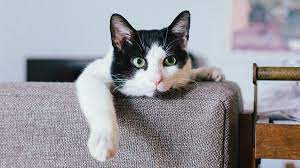

**Question 8** With Rmarkdown insert a code chunk and give an example of a simple mathematical calculation in it.

```r
x <- 276
y <- 89
x + y /2
```

```
## [1] 320.5
```

**Question 9** With $LaTeX$ write your favorite equation in block form.

$$\sum_{k=1}^{n}\frac{1}{n^2}=\frac{\pi^2}{6}$$

**Question 10** In a code chunk calculate 3 + 4.

```r
3 + 4
```

```
## [1] 7
```